# Student Attendance in SPGA 2025/26

Author

Stefano Pagliari

Published

May 7, 2026

# 1 Introduction

The analysis in this section explores in-person attendance across three departments in the School of Policy and Global Affairs (SPGA) in 2025/26: Economics, International Politics, and Sociology & Criminology.

This report provides a descriptive overview of overall attendance trends across the three SPGA departments for 2025/26, situating these figures in context by comparison with other academic years and departments, and examining variation in attendance across cohorts, timetable, class size, individual student characteristics and other factors. Finally, the report deploys a statistical analysis to isolate the independent contribution of a range of factors to the probability of a student attending any given session.

# 2 Data and Its Limitations

The analysis in this report explores draws on session records extracted from the attendance monitoring system at City St George’s. Attendance status for each session is determined by swipe records: a student is recorded as having attended if a valid swipe entry is present for that session. For the purpose of this analysis, late tapping is treated as attendance. The analysis focuses on undergraduate compulsory teaching sessions that are listed on the central timetabling website, excluding optional modules and sessions not formally scheduled.

These records are imperfect. On the one hand, the known phenomenon of “tap and leave” — where a student swipes in but does not remain for the session — means that recorded attendance may overstate actual engagement in some cases. On the other hand, analysis also necessarily misses cases where students attend a session without tapping their card, or where they attend a class not assigned to them in the timetable — neither of which is captured in the timetabling system. As far as can be determined, however, these data quality issues are not systematically associated with the main factors analysed below. While they inflate the overall attendance rate, they should not materially distort the analysis of correlates.

The dataset covers 406,715 attendance observations from 3,599 individual students across 190 modules, recorded during Terms 1 and 2 of the 2025/26 academic year. The overall attendance rate across all observations is 38.2%. Of these students, 1,996 have prior-year attendance records from 2024/5, which are used as a control in the statistical model. Prior-year mark data from 2024/5 are available for 1,949 students and are used to construct the past academic performance variable for second- and third-year students.

# 3 Attendance Across Departments

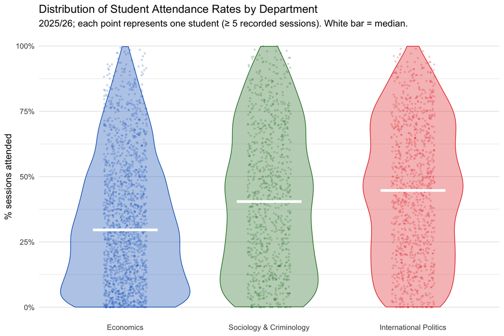

The violin plot reveals how attendance rates are distributed across individual students within each of the three SPGA departments, rather than simply comparing averages. The distributions differ markedly across departments, both in their central tendency and in their shape.

Economics shows the lowest median attendance of the three departments, with the bulk of its distribution concentrated below 50%. The violin is widest in the lower range, indicating that a large share of Economics students attend fewer than half of their scheduled sessions. This pattern is notably different from the other two departments and suggests a structural challenge that goes beyond a small group of chronically absent individuals.

Sociology & Criminology occupies a middle position, with a median of approximately 40–45% and a more evenly spread distribution. While there is substantial variability among students, the distribution does not concentrate as sharply at the low end as Economics, and a meaningful proportion of students achieve higher attendance rates.

International Politics shows the highest median attendance of the three, with a distribution that is wider at the upper end and displays a modest bimodal character — a concentration of students attending consistently at high rates alongside a lower tail of less engaged students. These differences in distributional shape, rather than average levels alone, point to where targeted support may be most needed, with Economics standing out as the department where low attendance is most prevalent and most systematic.

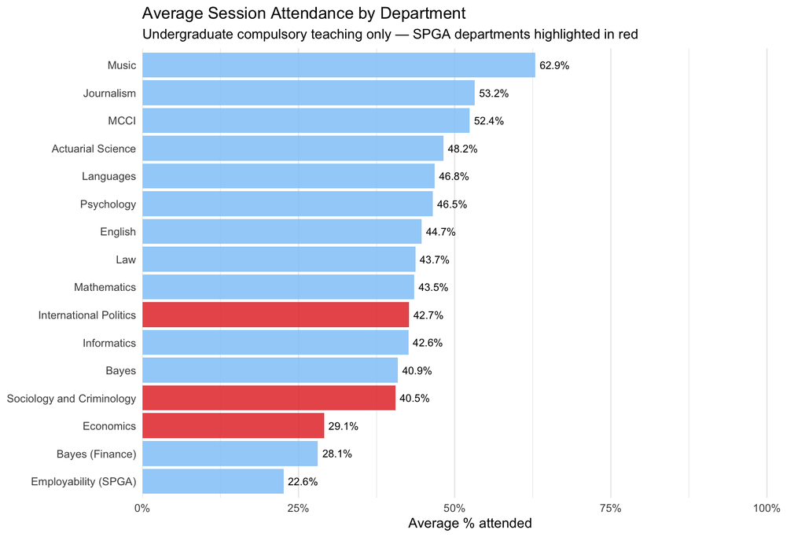

The three SPGA departments occupy different positions in the university-wide ranking, and the differences between them are substantial. International Politics, at 42.7%, sits broadly in the middle of the distribution, comparable to Mathematics (43.5%) and Informatics (42.6%). Sociology & Criminology, at 40.5%, is somewhat below the midpoint, broadly in line with the Bayes Business School average. Economics, at 29.1%, is near the bottom of the distribution — above only Bayes Finance (28.1%) and the Employability module (22.6%), both of which have very different teaching structures. This places Economics as a clear outlier within the SPGA, with attendance levels markedly lower than its peer departments in the school.

The highest-attending departments — Music, Journalism, and MCCI — deliver a substantial share of their teaching through practical studio, production, and performance-based activities where physical presence is operationally required. When SPGA departments are compared against lecture- and seminar-based disciplines more similar in structure, International Politics and Sociology & Criminology perform comparably; Economics, however, falls significantly below this peer group as well.

# 4 Comparison with Previous Academic Years

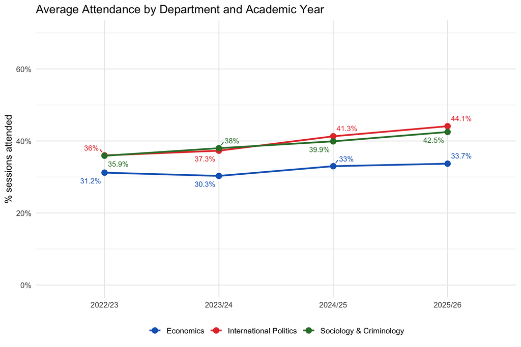

Across the three SPGA departments, attendance in 2025/26 is broadly in line with 2024/25. Note that Economics and Sociology & Criminology may have limited records in earlier academic years depending on when data extraction began, so year-on-year comparisons for those departments should be treated with caution. For International Politics, where data extend back to 2022/23, comparisons with years prior to 2024/25 should also be read carefully given changes to the notification and reminder system for domestic students introduced around that time; earlier years may therefore not be fully comparable.

# 5 Attendance and Timetabling

## 5.1 Within and Across Terms

The chart below show two consistent patterns. First, attendance declines progressively within each term: the later the week, the lower the average attendance rate, and this within-term erosion is visible in both Term 1 and Term 2. Second, attendance in Term 2 is substantially and consistently lower than attendance in the equivalent week of Term 1 — the gap opens from the very first week of the second term and is maintained throughout. These two patterns — within-term decline and a Term 2 level shift — are both confirmed by the multivariate model, which shows that they persist after controlling for timetabling, student characteristics, and module-level factors.

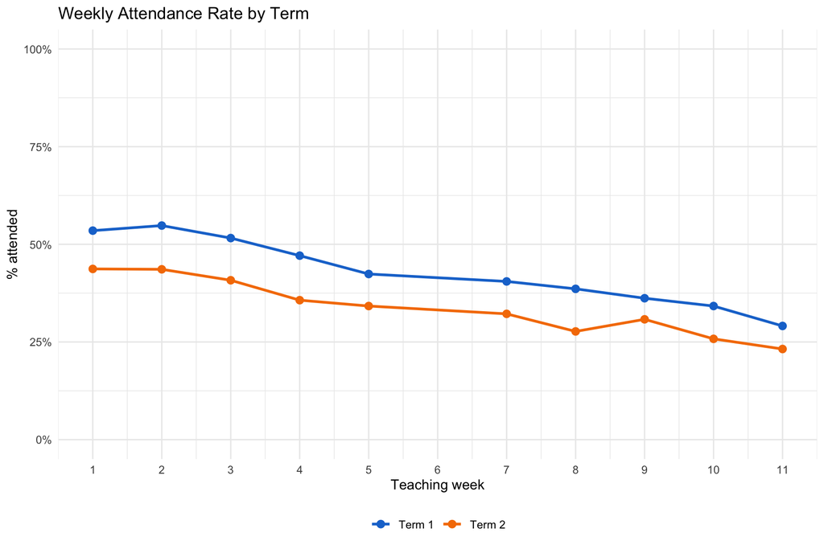

## 5.2 Day of Week

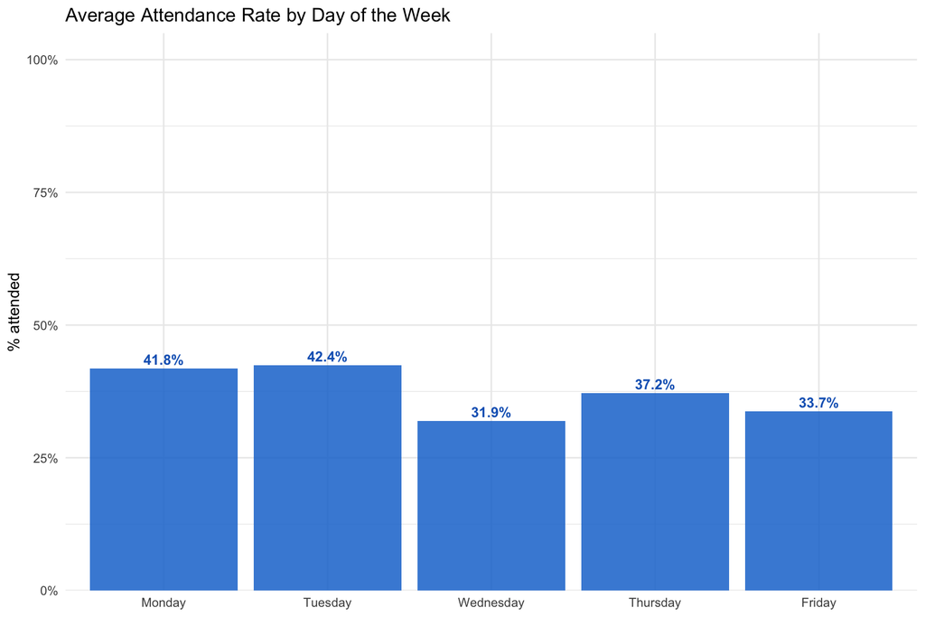

## 5.3 Time of the Day

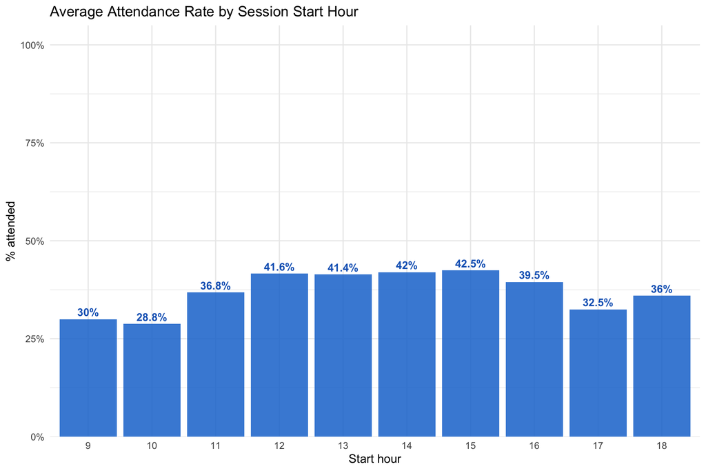

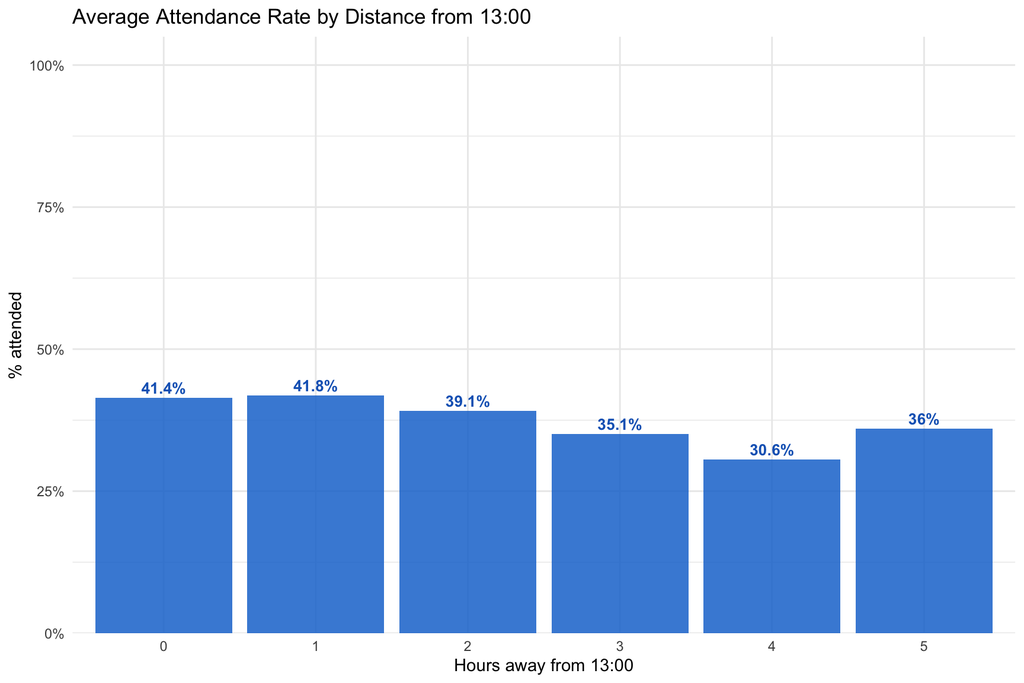

## 5.4 Number of Classes in the Day

The chart below shows average attendance by the number of other sessions of the **same delivery mode** a student has scheduled on the same day. Students with a single on-campus (or online) session on a given day attend just 35.9% of their classes on that day on average — the lowest of any group. Attendance rises as the number of same-mode sessions increases: students with two same-mode sessions average 39.4%, and those with three record 43%. Students with four same-mode sessions average 41.3%, suggesting that the benefit levels off or dips slightly on the busiest days. Separating by delivery mode refines the earlier finding: the “sunk cost of commuting” logic applies specifically within a mode — the commitment of travelling to campus (or logging into an online session) appears to lower the marginal cost of attending subsequent sessions of the same type. This positive association is confirmed by the multivariate model.

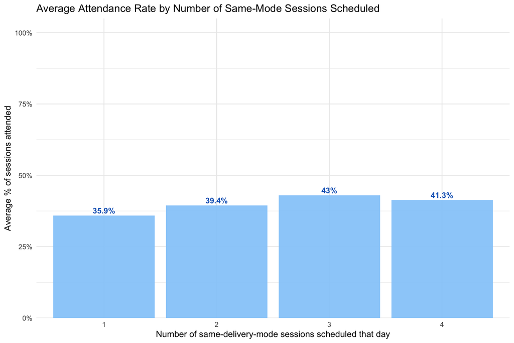

# 6 Attendance by Year of Study

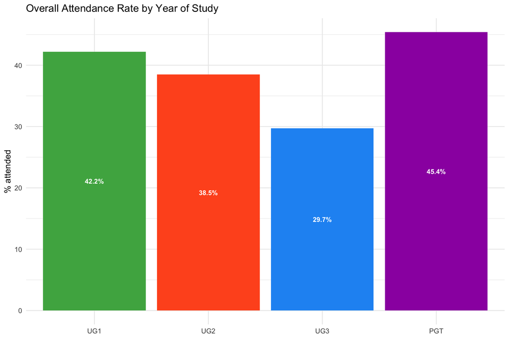

# 7 Attendace by Class Size

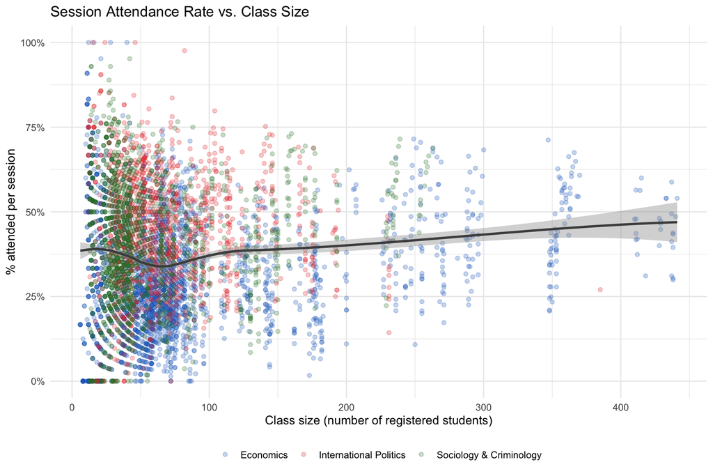

# 8 Attendance by Delivery Mode

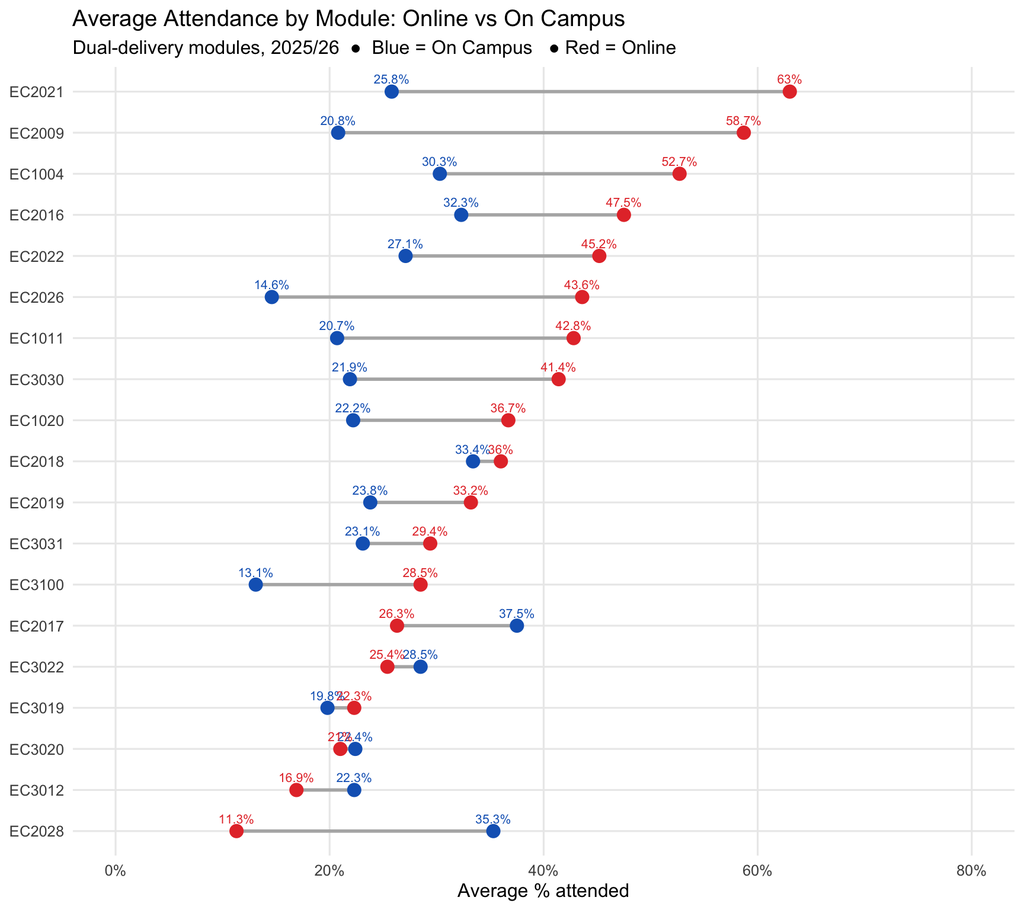

The chart restricts the comparison to **modules that run sessions in both delivery modes in 2025/26**, and within those modules excludes in-person lectures — which have no online counterpart. Online sessions are identified by the presence of a virtual room or an “Online” session-type label; in-person sessions are all remaining non-lecture slots (tutorials, labs, seminars) in the same modules. In 2025/26, the sessions meeting this criterion are predominantly Economics tutorials and lab sessions.

The median attendance for on-campus sessions in this matched sample is 24.4%, compared to 36.7% for their online counterparts. This within-module, within-session-type comparison is what the multivariate model is capturing when it reports a higher odds ratio for online delivery: once session type, module, and department are held constant, online sessions see relatively higher attendance than equivalent in-person ones, likely because logging in from home carries a lower barrier than travelling to campus.

# 9 Attendance and Individual Student Characteristics

## 9.1 Prior-Year Attendance

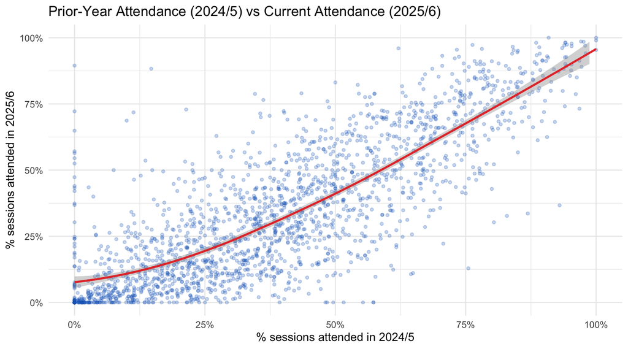

Prior-year attendance is one of the strongest student-level predictors of current-year attendance. Students who attended reliably in 2024/5 tend to do so again in 2025/6, and those who missed frequently last year continue to miss at higher rates this year. The positive association is visible across the full range of attendance values, though with considerable spread around the LOESS curve, indicating that prior attendance is a useful but far from deterministic signal. This persistence in attendance behaviour supports its inclusion in the statistical model as a control, where it is among the largest fixed-effect estimates.

## 9.2 Distance from Campus

Distance is measured as the straight-line distance in kilometres between the campus postcode (EC1V 0HB) and the postcode of each student’s registered home address, geocoded via the postcodes.io API. This is an approximation of commuting distance and does not reflect the student’s actual mode of travel or the route taken.

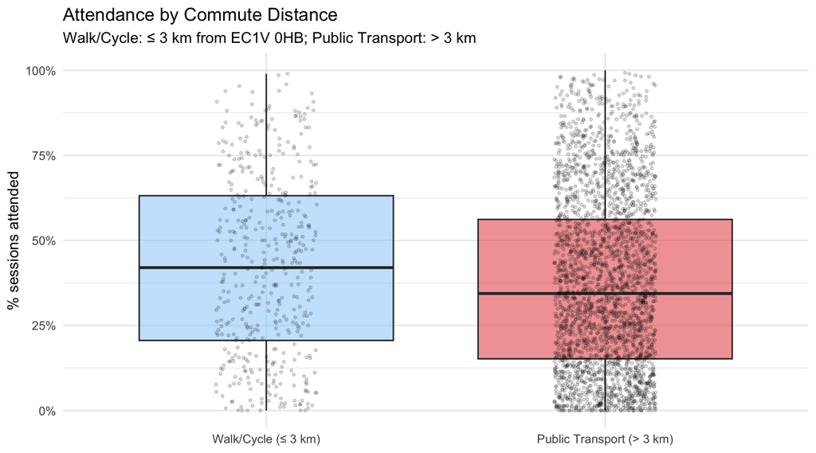

Splitting students at the 3 km threshold — roughly the boundary between those who can walk or cycle to campus and those who depend on paid public transport — reveals a modest gap in median attendance: 42% for students within walking or cycling distance versus 34.4% for those relying on public transport.

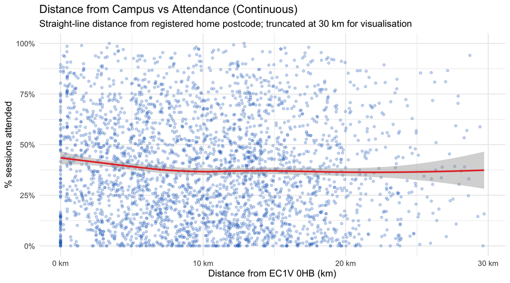

The continuous measure confirms a similar picture, but the negative relation between distance and attendance is only shallow, with no clear threshold beyond which attendance drops sharply.

## 9.3 Past Academic Performance

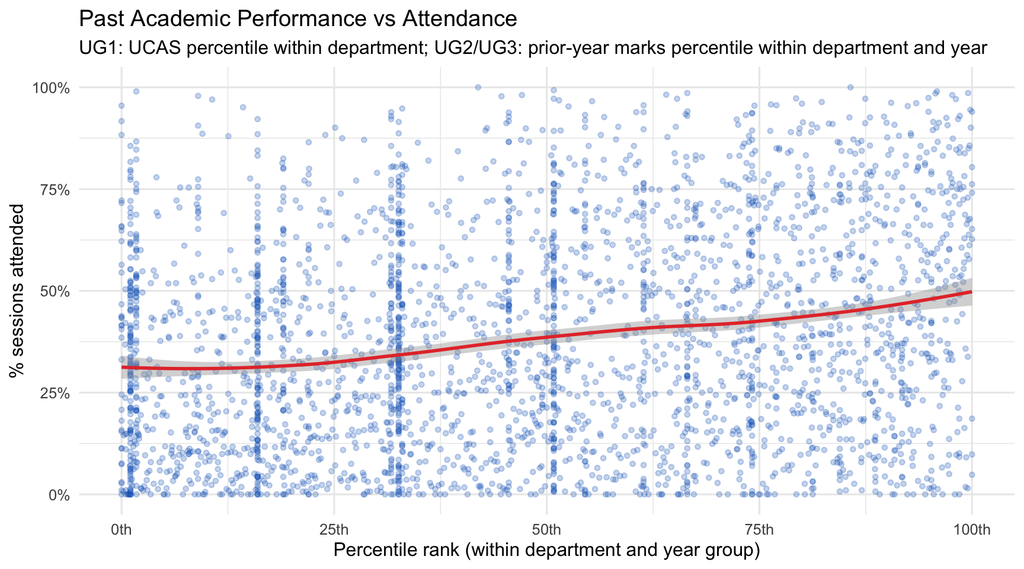

Students who performed better academically relative to their peers tend to have higher attendance. For first-year students, where no university marks are yet available, the measure draws on UCAS entry points ranked within their department; for second- and third-year students, it uses their 2024/5 average mark ranked within their department and year. The LOESS curve shows a gradual positive slope. This relationship holds alongside prior attendance in the statistical model below.

## 9.4 Visa Status

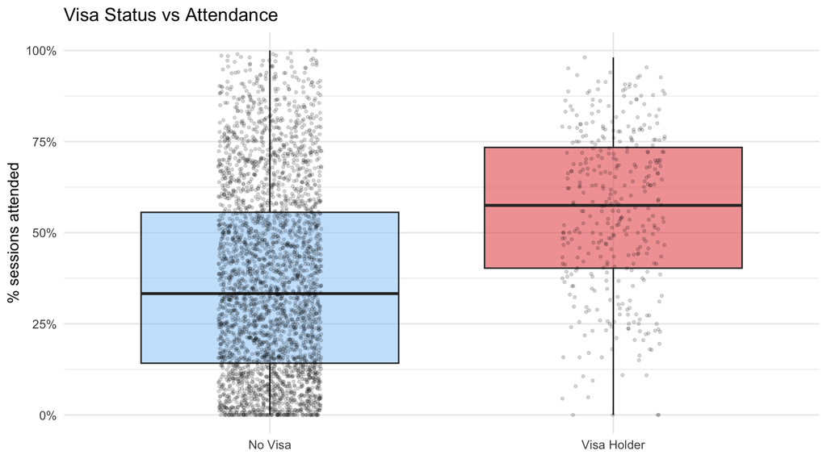

Visa status shows one of the clearest and most consistent attendance gaps in the data. Students on a UK Student visa attend at substantially higher rates than their non-visa peers, with a separation visible in both the medians and the shape of the distributions: the visa-holder distribution is more tightly clustered at the upper end, while the non-visa distribution has a much longer lower tail. This pattern directly reflects the compliance incentive built into the UK Student visa regime, under which universities are required to monitor and report attendance, and students risk losing their visa status if they fall below the required threshold. The model estimates this as one of the largest individual-level effects in the data.

## 9.5 Admission Mode (Clearing vs Direct Entry)

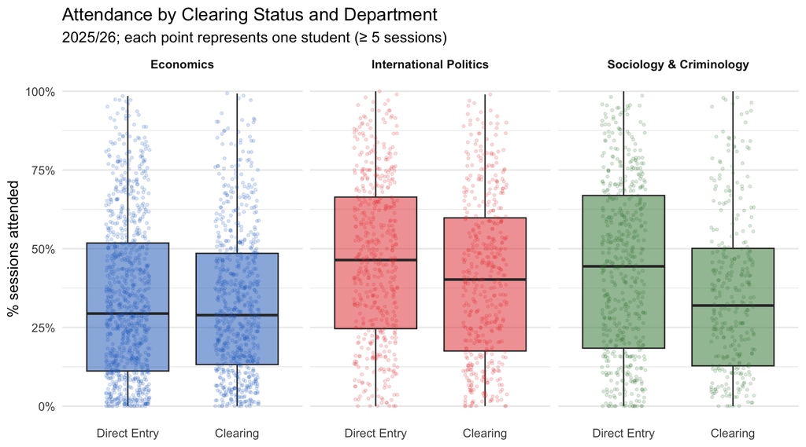

# 10 Statistical Analysis

## 10.1 Model Specification

To identify the independent drivers of attendance, the analysis estimates a multilevel logistic regression model. The multilevel structure is necessary because the data are hierarchical: individual session-attendance records are nested within students, and the same student appears across multiple records. A random intercept for each student is therefore included, allowing baseline attendance propensity to vary across individuals while the fixed-effect estimates capture within-student variation in response to session- and module-level factors.

The fixed-effects predictors cover student characteristics (prior attendance history, past academic performance), session attributes (day of week, time of day, term, week of term), module-level factors (class size, number of modules scheduled on the same day), and year of study (UG1–UG3 and PGT). Department fixed effects are also included to capture systematic differences in attendance levels across Economics, International Politics, and Sociology & Criminology that are not explained by any of the other variables. By holding all these factors constant simultaneously, the model isolates the independent contribution of each predictor.

Past academic performance is constructed differently by year of study, to reflect what prior academic information is available for each cohort. For first-year undergraduates (UG1), no university marks exist at the point of entry, so the variable is the student’s percentile rank on UCAS entry points within their department. For second- and third-year undergraduates (UG2 and UG3), it is the student’s percentile rank on their 2024/5 average mark, computed within their department and year group. In both cases the variable is scaled to a 0–100 percentile, so a one-standard-deviation increase has a comparable interpretation across years. For PGT students the variable is not available and is set to the sample mean (effectively contributing zero variation for that group).

Effect sizes are reported as odds ratios (OR): values above 1 indicate higher odds of attending, values below 1 lower odds. An important clarification on language: an OR does not express a percentage-point change in the attendance rate. It expresses a *relative* change in the odds of attending compared to the reference group or baseline. For example, an OR of 0.84 means the odds of attending are 16% lower — but if the baseline attendance rate is around 70%, this translates to roughly a 3–4 percentage point reduction in the actual probability of attending, not 16 points. Where the text below says a factor “increases/reduces the odds by X%”, this always refers to this relative change in odds. Because the large sample size naturally produces statistically significant p-values across the board, confidence intervals and the magnitude of the odds ratios are used to assess the practical importance of each finding.

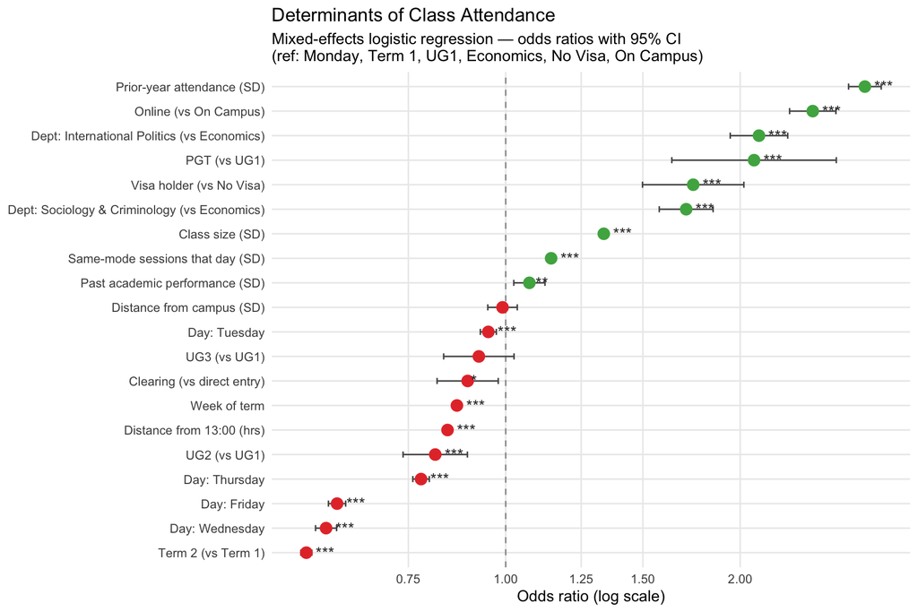

## 10.2 Summary of Findings

[output not shown]